# Why Use R Markdown?

An excursion into knitting in the name of scientific glory

Andres Karjus

# Background check

# What IS R Markdown?

- …an authoring format that enables easy creation of dynamic documents, presentations, and reports from **R**
- combining the core syntax of *Markdown*
- with embedded R code chunks that are run so their output can be included in the final document.
- Publishing into a variety of formats using the `knitr` package.
- Supports language engines other than R, e.g. Python, Ruby, Haskell, Bash, Perl; C++ using `Rcpp`
- pdfs using `pandoc` & Latex (e.g., MikTex on Windows)

# What is Markdown?

- A plain text formatting syntax.
- The overriding design goal for Markdown: Markdown-formatted document should be publishable as-is, as plain text, without looking like it’s been marked up with tags or formatting instructions.

# The “before” picture

1. keep your data in one or more files (txt, excel)
2. import data to R
3. build models, analyze data, make nice plots
4. export plots to png, jpeg, pdf files
5. open Word, write up a report/paper/book | open Powerpoint, make slides
6. copy plots from image files to said document/slides

# The “before” picture

7. realize you made a mistake in the analysis
8. GoTo 2, repeat, copy, paste
9. realize you promised to send the code or the results to your supervisor/colleague/buddy for review
10. copy pieces of code, model output or plot images, attach the bunch to email
11. realize you accidentally sent plot images from the wrong folder
12. ?
13. Profit!

# Why You should use R Markdown to author slides, simple websites, documents and more?

- It’s easy
- …like really really easy.
- It saves time (because it’s easy AND powerful). Life is short.
- Since you already use **R** for your research (if you do :)
- Keep your code, analyses, plots and interpretations/text all in one place

# Why You should use R Markdown to author slides, simple websites, documents and more?

- Flexible. Use the same R Markdown file to generate a research report (pdf, doc), slides, websites (html without writing any html yourself), to produce output for papers (or books:) complete with figures, tables, bibliographies, Latex equations and formatting.
- Reduces manual copy-paste work -> reduces chance of manual error

# Why You should use R Markdown to author slides, simple websites, documents and more?

- Reproducible research!
- With a little extra effort: integrate interactive components (from adjustable plots to simulations) in your website/slides
- You can include html, css, javascript - but you don’t have to.

# The it being easy part

- Remember the “overriding desing goal”? It’s supposed to look all right in plain text.
- What do you think the following markdown code does - hint, it’s about text formatting: `**bingo**`
- **bingo!**
- OK how about this: `_indeed_`
- *indeed*

# The it being easy part

- This makes a bullet point: `*` (like the bullets on this slide)
- Mkay riddle me this, what’s the difference:
  - `# An Introduction to Stuff`
  - `## Basic Components of Stuff`
- `![](photo.png)` ?

# That was the Markdown part, now for the R part

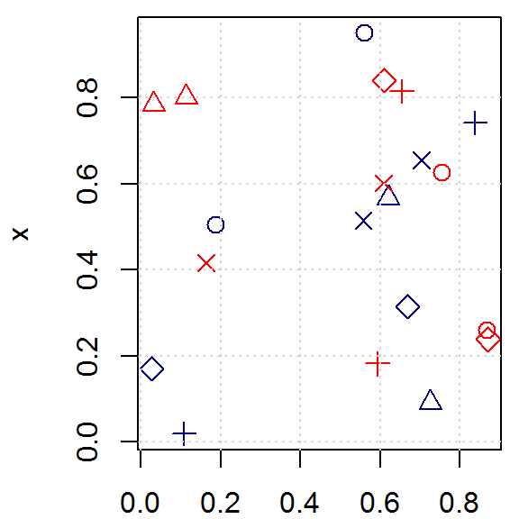

The code chunk for inserting that plot looks like this:

```r
plot(x, y) # plus some visual parameters...
```

The value of you see here, 3.9633273, is not static, but calculated on document creation from this inline code snippet: `r` `sqrt(pi*5)`.

# Bring out some bigger guns

# Embedded Shiny applications for interactive slides and websites

[requires active Shiny runtime; this is a static copy]

# Latex support for equations and such

The relationship between $X \in [0,1]$ and the variable $Y$ is shown to be $X = 0.76Y + a$, where $a$ is the Stuff constant, with a value of $\pi/e^2$. Also feast your eyes on these random explosion of mathematical prowess:

$\sum_{i=1}^n i = \left(\sum_{i=1}^{n-1} i\right) + n =\frac{(n-1)(n)}{2} + n = \frac{n(n+1)}{2}$

$$\mathbf{m} = \left[\begin{array}
{rrr}
1 & 2 & 3 \\
4 & 5 & 6 \\
7 & 8 & 9
\end{array}\right]$$

# Moar plotts?

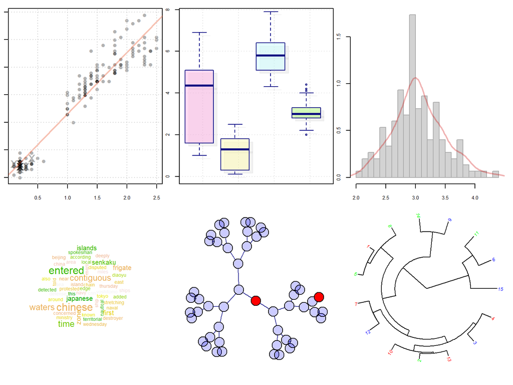

# Bibtex & CSL formatting support for citations and bibliographies

…bla bla bla, as discussed in Blazcerny et al. (2004).  
*Abrams, D. M., & Strogatz, S. H. (2003). Modelling the dynamics of language death. Nature, 424, 900.*  
*Bloem, J., Versloot, A., & Weerman, F. (2015). An agent-based model of a historical word order change. In Proceedings of the sixth workshop on cognitive aspects of computational language learning (pp. 22-27). Lisbon, Portugal: Association for Computational Linguistics.*  
*Kirby, S., Cornish, H., & Smith, K. (2008). Cumulative cultural evolution in the laboratory: An experimental approach to the origins of structure in human language. Proceedings of the National Academy of Sciences, 105(31), 10681-10686.*

# Example use case 1

- A simple website (e.g., a CV) with a couple of images, links and tabbed subsections.
- Could include bibliography of the author
- The same R Markdown code can be used to create the website, a doc or pdf.

# Example use case 2

- An internal project website, updated weekly with the upcoming and completed goals of the project, displaying the R code for the analyses and plotting of the results, along with the actual plots.
- The same R code is used to carry out the analyses, the results and plots on the websites are thus updated automatically.
- The very same code can be used to produce plots for presentation slides and papers.
- It is trivial to generate a Word doc or pdf from the same Markdown that is used to create the website (keeping all the text, code and plots of course).

# Example use case 3

- An interactive website showcasing a model of data analysis or results from one.
- The interactive component relies on Shiny
- The rest (e.g., explanation) is in R Markdown

# Example use case 4

- Slides for a conference, lecture or seminar (**like this one right here**)
- Similarly can be exported in a variety of formats
- `slidy` for example allows for dynamic zooming of text to suit different presentation screens

# Bottom line

- Don’t waste you precious time
- Do your stuff in one place
- Particularly if your stuff includes anything **R** (or another language) and one of: authoring papers, slides, websites
- You change your code -> your text and plot change automatically
- But also if you’d like to integrate creating equations, bibliographies and writing up stuff, but don’t like going all out Latex.
- Even if you do your data analysis in SPSS or Excel or whereever, you might be interested in **R**’s extensive plotting capabilities - all fully exploitable when using R Markdown.